# Implementation of Bentley-Ottmann Sweep Line Algorithm to find Intersections of Line Segments

## Problem Statement

**Given a set of line segments, compute all the intersection points of these line segments.**

### Components of the algorithm

The algorithm maintains two data structures and a vertical sweepline.

- The vertical sweepline processes all events from left to right.
- The Event Queue data structure keeps track of all notable points (events). A point is considered notable if a line segment starts, ends or intersects with other line segments there.
- The Status Queue data structure maintains the ordering of line segments (by y coordinate), given the current position of the sweepline (its x coordinate).

### The algorithm

- The algorithm performs a vertical line sweep processing events from left to right.
- Initially, all the starting and ending points of the line segments are inserted into the Event Queue.

**Key Observation:** A line segment must intersect with at least one segment adjacent to it in the Status Queue for it to intersect at all.

- All adjacent pairs of line segments are checked for intersections which are reported when found.
- Every time an insertion or a deletion causes a new pair of line segments to be adjacent, they are again checked for intersection. When found, intersections are reported and new events are created and inserted into the Event Queue.
- The algorithm ends when the Event Queue becomes empty.

#### Pitfalls:

- This implementation is precise upto 9 decimal places, after which accuracy starts dropping.
- Two line segments which coincide with each other either partially or in whole have infinitely many points of intersection. This implementation assumes the input does not have any such cases.

# Timing Analysis

```python
import pandas as pd
import numpy as np

df = pd.read_csv("benchmark.csv")
df["n+k logn"] = (df["num_segments"] + df["num_intersections"]) * np.log(df["num_segments"])
df.rename(columns={"num_segments": "num_segments (n)", "num_intersections": "num_intersections (k)"}, inplace=True)
df[["cpu_time", "num_segments (n)", "num_intersections (k)", "n+k logn"]].describe()
```

|  | cpu_time | num_segments (n) | num_intersections (k) | n+k logn |
| --- | --- | --- | --- | --- |
| count | 7.500000e+01 | 75.000000 | 7.500000e+01 | 7.500000e+01 |
| mean | 6.547903e+08 | 2695.266667 | 3.579139e+05 | 2.819343e+06 |
| std | 1.147495e+09 | 2420.559112 | 5.965197e+05 | 4.877760e+06 |
| min | 1.048570e+03 | 3.000000 | 1.000000e+00 | 4.394449e+00 |
| 25% | 3.371280e+06 | 931.000000 | 1.000000e+00 | 4.885766e+04 |
| 50% | 1.466180e+08 | 1737.000000 | 9.619200e+04 | 6.337277e+05 |
| 75% | 6.991820e+08 | 3638.000000 | 4.231680e+05 | 3.050935e+06 |
| max | 5.502120e+09 | 9603.000000 | 2.767870e+06 | 2.297103e+07 |

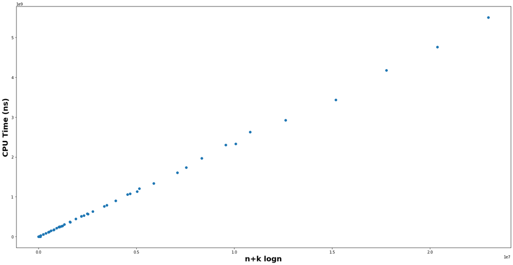

```python
import matplotlib.pyplot as plt

plt.figure(figsize=(24, 12))
plt.scatter(df["n+k logn"], df["cpu_time"])
plt.xlabel("n+k logn", fontdict={"fontsize": 20, "fontweight": "bold"})
plt.ylabel("CPU Time (ns)", fontdict={"fontsize": 20, "fontweight": "bold"});
```

The plot of CPU Time against $(n+k) logn$ is approximately linear Therefore, $$ \text{CPU Time} \propto (n+k)logn $$ Hence, this empirically proves the relation $$ T(n, k) = \Theta((n+k)logn) $$

# Visualization of some test cases

```python
import os
import matplotlib.pyplot as plt
import matplotlib.lines as mlines
import seaborn as sns

sns.set_style("darkgrid")
sns.set_context("talk")
sns.set_palette("magma")

plt.rcParams["figure.edgecolor"] = "black"
plt.rcParams["axes.edgecolor"] = "black"
plt.rcParams["axes.linewidth"] = 2.50
```

```python
def getInput(filepath):
    with open(filepath, 'r') as f:
        lines = f.read().splitlines()

    n = int(lines[0])
    segments = []
    for i in range(1, n+1):
        coords = [float(x) for x in lines[i].split()]
        segments.append([(coords[0], coords[1]), (coords[2], coords[3])])

    points = []
    with open(os.path.join(os.path.dirname(filepath), "expected", os.path.basename(filepath)), 'r') as f:
        lines = f.read().splitlines()
        m = int(lines[0])
        for i in range(1, m+1):
            points.append(tuple([float(x) for x in lines[i].split()][:2]))
    return {"segments": segments, "points": points}

def plotData(data, ax=None, figsize=(8,8), markerSize=50, showEndPoints = True, showCoords = True, monochrome = False, showLegend = True):
    if ax is None:
        plt.figure(figsize=figsize)
        ax = plt.gca()
    for line in data["segments"]:
        if monochrome:
            ax.plot([line[0][0], line[1][0]], [line[0][1], line[1][1]], zorder=1, color="blue")
        else:
            ax.plot([line[0][0], line[1][0]], [line[0][1], line[1][1]], zorder=1)
        if showEndPoints:
            ax.scatter([line[0][0], line[1][0]], [line[0][1], line[1][1]], zorder=2)
    for point in data["points"]:
        ax.scatter(point[0], point[1], color="orange", edgecolors="black", s=markerSize, zorder=3)
        if showCoords:
            ax.text(point[0]+0.1, point[1]+0.15, f"({point[0]}, {point[1]})", fontsize=9, fontweight="bold", zorder=4)
    if showLegend:
        scatterpoint = mlines.Line2D([], [], color="orange", marker="o", markersize=10, markeredgecolor="black", markeredgewidth=1.5, ls="")
        ax.legend(handles=[scatterpoint], labels=[len(data["points"])], loc="upper right", prop={'size': 20, 'weight': 'bold'}, framealpha=1)

def plotSubplots(files, nrows, ncols, figsize=(12,12)):
    plt.figure(figsize=figsize)
    for i, filepath in enumerate(files):
        data = getInput(filepath)
        plotData(data, plt.subplot(nrows, ncols, i+1))
    plt.tight_layout()
```

## Oblique Grid

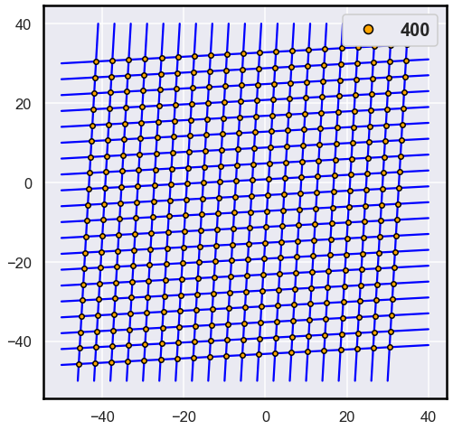

```python
plotData(getInput('../data/oblique_parallel_lines.txt'), showEndPoints=False, showCoords=False, markerSize=30, monochrome=True)
```

## Parallel non-intersecting lines

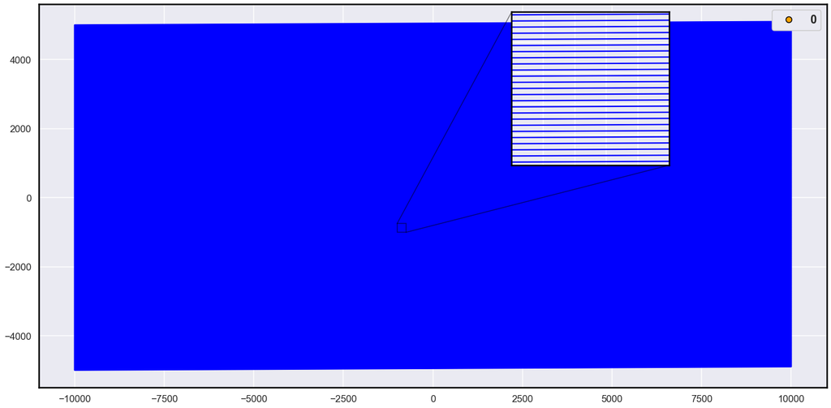

```python
plotData(getInput('../data/parallel_lines.txt'), figsize=(24,12), showCoords=False, showEndPoints=False, monochrome=True)
ax = plt.gca()
axins = ax.inset_axes([0.6, 0.58, 0.2, 0.4])
plotData(getInput('../data/parallel_lines.txt'), ax=axins, figsize=(24,12), showCoords=False, showEndPoints=False, monochrome=True, showLegend = False)
axins.set_xlim(-1000, -750)
axins.set_ylim(-1000, -750)
axins.set_xticklabels([])
axins.set_yticklabels([])
ax.indicate_inset_zoom(axins, edgecolor="black");
```

## Star at Origin

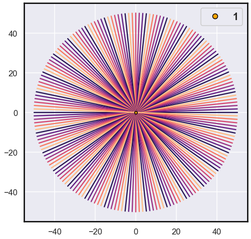

```python
plotData(getInput('../data/star_at_origin.txt'), showCoords=False, showEndPoints=False, markerSize=30)
```

## Random line segments

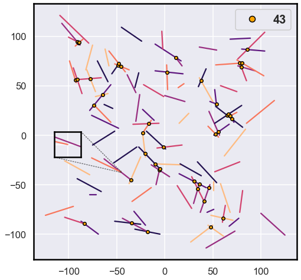

```python
plotData(getInput('../data/rand1.txt'), showCoords=False, showEndPoints=False, markerSize=30)
ax = plt.gca()
axins = ax.inset_axes([0.08, 0.4, 0.1, 0.1])
plotData(getInput('../data/rand1.txt'), ax=axins, showCoords=False, showEndPoints=False, showLegend = False)
axins.set_xlim(-46.25, -45.75)
axins.set_ylim(-37.5, -36.5)
axins.set_xticklabels([])
axins.set_yticklabels([])
rect, conn = ax.indicate_inset_zoom(axins, edgecolor="black", linewidth=1.5)
plt.setp(conn, linestyle=":");
```

## Special cases

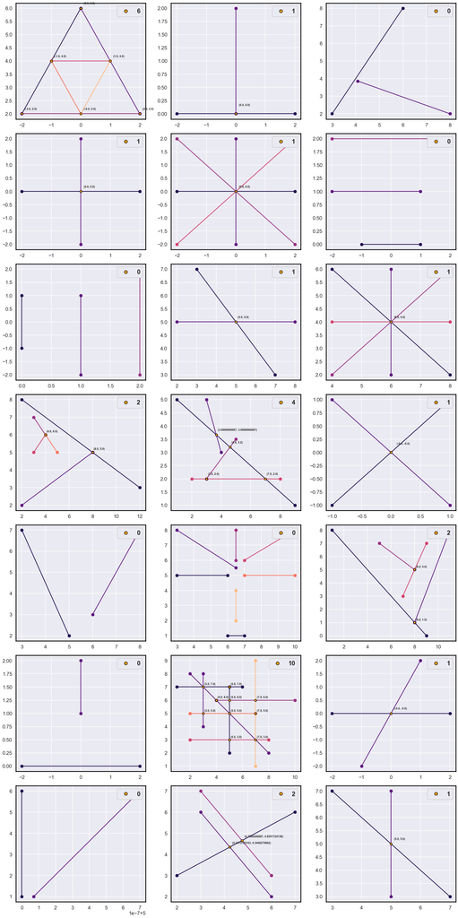

```python
import re
pattern = re.compile("edge_case.*")

files = [os.path.join("../data", filename) for filename in os.listdir("../data") if pattern.match(filename)]
plotSubplots(files, 7, 3, figsize=(21, 42))
```